# AjusteVariablesPython

## Practica :

Generar un modelo que me permita simular el uso de recursos de los hospitales por cada una de las provincias, para ello obtener la informacion revisada en la practica de investigacion y tomar como ejemplo la practica de simulacion de atencion de paciente del COVID revisada en clase. Lo que se busca es poder generar graficos de uso de recursos:

- Costos (Generar un aproximacion de cuanto se invierte para atender a un paciente con COVID)
- Personal (Aproximacion del uso del personal por paciente, o el hospital)
- Camas
- Equipos/Insumos medicos (Obtener una aproximacion del uso de equipos medicos)
- Pacientes (Informacion obtenida desde el ministerio de salud - validar con el porcentual del tipo de paciente [ninio 10%, adulto 30%, riesgo 60%]) - Hospitalizacion 80%, Otros 20%

Para ello deberan generar un modelo lo mas cercano a la realidad, y con ayuda de la estadistica descriptiva ajustar los valores. Es importante tener como datos de entrada el dia y el numero de pacientes.

Finalmente validar el modelo con lo la realidad del pais (Investigar en base al tema el uso de los recursos publicos )

### (Chimborazo): Hospital General Docente

**Costo pacientes bajo riesgo:** 3.500

**Personal por paciente:** 6

**Camas:** 300

**Respiradores:** 5

**UCI:** 5

**Acceso a la UCI:** 30% pacientes

### Obtener tasa de crecimiento de la provincia

```python
import pandas as pd
import numpy as np

url = 'Casos.xlsx'
df = pd.read_excel(url)
df = df.replace(np.nan, 0)
df=df[df['Provincia']=="Chimborazo"]
filtro = df.iloc[0].loc['19/3/2020':]
media = filtro.mean()
print(media)
```

```
48.97142857142857
```

[output not shown]

[output cut: 3205 more lines]

[output not shown]

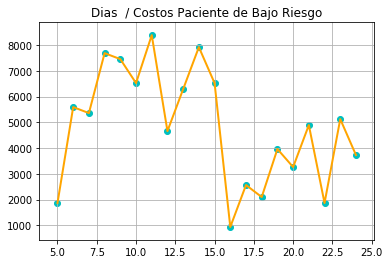

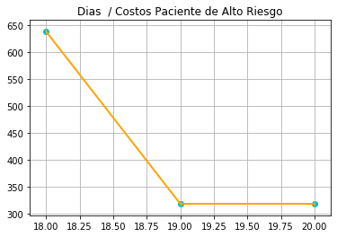

```
Costo Total: 97971 $
```

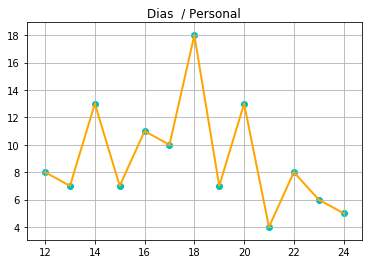

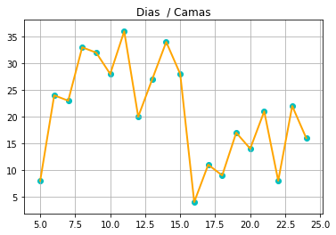

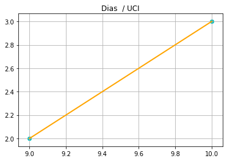

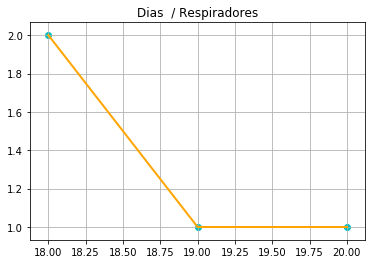

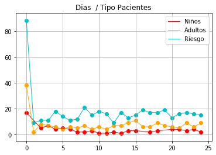

```python
import simpy
import random
import matplotlib.pyplot as pp
import numpy as np

%matplotlib inline

#PARAMETROS
HOSPITALES = 1
CAMAS = 300
RESPIRADORES=5
UCI=5
PERSONAL=115

INFECTADOS= 299
TASA_CRECIMIENTO = 48
DIAS_INTERNADO = 10
DIAS_SIMULACION = 25


ALTO_COSTO=6700
DIA_ALTO=int(ALTO_COSTO/21) #Tiempo promedio de recuperación total
BAJO_COSTO=3500
DIA_BAJO=int(BAJO_COSTO/15) #Tiempo promedio de recuperación total

riesgo={}
niños={}
adultos={}
atendidos={}
costoTotal=[]
personalTotal={}
TotalCamas={}
respiradoresTotal={}
UCITotal={}


persona_recuperadas={}
persona_fallecidas={}


class Hospital(object):

    def __init__(self, env,num_cama,name,num_personal,num_uci, num_respiradores):
            self.env = env
            self.num_cama = num_cama
            self.num_personal = num_personal
            self.num_uci=num_uci
            self.num_respiradores=num_respiradores
            self.camas = simpy.Resource(env, num_cama)
            self.personal = simpy.Resource(env, num_personal)
            self.uci = simpy.Resource(env, num_uci)
            self.respiradores = simpy.Resource(env, num_respiradores)
            self.name = name

    def ingresar(self, paciente):
        yield self.env.timeout(random.randint(DIAS_INTERNADO-5, DIAS_INTERNADO+5))
        print("Paciente Nº", paciente, "salió de la hospitalización en el día ", int(self.env.now))

    def ucis(self, paciente):
        yield self.env.timeout(random.randint(DIAS_INTERNADO-3, DIAS_INTERNADO+11))
        print("Paciente Nº", paciente, "salió de la UCI en el día ", int(self.env.now))

    def asignar_respiradores(self, paciente):
        yield self.env.timeout(random.randint(DIAS_INTERNADO-3, DIAS_INTERNADO+11))
        print("Paciente Nº", paciente, "suspensión de respiradores en el día ", int(self.env.now),'por muerte.')


def llegada_paciente(env, hospital, paciente):
    arrive = env.now
    estado = random.randint(1,100)
    if (estado < 80) :
        tipo = random.randint(1,100)
        if (tipo < 10) :
            niños[env.now] = niños[env.now] + 1 if env.now in niños else 1
        elif(tipo < 30 and tipo>10) :
            adultos[env.now] = adultos[env.now] + 1 if env.now in adultos else 1
        elif (tipo > 60) :
            riesgo[env.now] = riesgo[env.now] + 1 if env.now in riesgo else 1

        with hospital.camas.request() as cama:
            llegadaC = env.now
            dias_esperando = random.randint(0,2) #Numero de dias maximo que puede esperar sin ser asignado a una cama dentro del hospital
            requerimientoC = yield cama | env.timeout(dias_esperando)
            wait = env.now - llegadaC
            if cama in requerimientoC:
                print("Paciente Nº", paciente, " se le asigna una cama ")
                yield env.process(hospital.ingresar(paciente))
                estado = random.randint(1,100)
                TotalCamas[env.now] = TotalCamas[env.now] + 1 if env.now in TotalCamas else 1
                atendidos[env.now] = atendidos[env.now]+ 1 if env.now in atendidos else 1

                if (estado < 8) :
                    persona_fallecidas[env.now] = persona_fallecidas[env.now] + 1 if env.now in persona_fallecidas else  1
                else:
                    persona_recuperadas[env.now] = persona_recuperadas[env.now] + 1 if env.now in persona_recuperadas else 1

                ###  ASIGNAR PERSONAL  ###
                with hospital.personal.request() as personal:
                    llegadaP = env.now
                    dias_esperando = random.randint(0,1) #Numero de dias maximo que puede esperar sin ser asignado el personal dentro del hospital
                    requerimientoP = yield personal | env.timeout(dias_esperando)
                    waitP = env.now - llegadaP
                    if personal in requerimientoP:
                            print("Paciente Nº", paciente, " se le asigna personal medico ")
                            yield env.process(hospital.ingresar(paciente))
                            estado = random.randint(1,100)
                            personalTotal[env.now] = personalTotal[env.now] + 1 if env.now in personalTotal else 1
                            if (estado < 8) :
                                persona_fallecidas[env.now] = persona_fallecidas[env.now] + 1 if env.now in persona_fallecidas else  1
                            else:
                                persona_recuperadas[env.now] = persona_recuperadas[env.now] + 1 if env.now in persona_recuperadas else 1
                    acceso = random.randint(1,100)
                    if(acceso<30): ### Probabilidad de necesitar acceso a la UCI

                        ### UCI ###
                        with hospital.uci.request() as uci:
                            llegadaU = env.now
                            dias_esperando = random.randint(9,15) #Numero de dias maximo que puede esperar sin ser asignado a una sala UCI del hospital
                            requerimientoU = yield uci | env.timeout(dias_esperando)
                            waitU = env.now - llegadaU
                            if uci in requerimientoU:
                                print("Paciente Nº", paciente, " pasa a la UCI ")
                                UCITotal[env.now] = UCITotal[env.now] + 1 if env.now in UCITotal else 1
                                yield env.process(hospital.ucis(paciente))
                                estado = random.randint(1,100)
                                if (estado < 8) :
                                    persona_fallecidas[env.now] = persona_fallecidas[env.now] + 1 if env.now in persona_fallecidas else  1
                                else:
                                    persona_recuperadas[env.now] = persona_recuperadas[env.now] + 1 if env.now in persona_recuperadas else 1

                                ###  RES  ####
                                requiere = random.randint(1,100)
                                if(requiere<95):
                                    with hospital.respiradores.request() as respiradores:
                                        llegadaR = env.now
                                        requerimientoR = yield respiradores | env.timeout(0)
                                        waitR = env.now - llegadaR
                                        if respiradores in requerimientoR:
                                            print("Paciente Nº", paciente, "se le asigna un respirador ")
                                            respiradoresTotal[env.now] = respiradoresTotal[env.now] + 1 if env.now in  respiradoresTotal else 1
                                            yield env.process(hospital.asignar_respiradores(paciente))
                                            estado = random.randint(1,100)
                                            if (estado < 8) :
                                                persona_fallecidas[env.now] = persona_fallecidas[env.now] + 1 if env.now in persona_fallecidas else  1
                                            else:
                                                persona_recuperadas[env.now] = persona_recuperadas[env.now] + 1 if env.now in persona_recuperadas else 1
                                        else:
                                            print("Paciente Nº" , paciente," espero ", waitR , " días y fallece por falta de acceso a respiradores")
                                            persona_fallecidas[env.now] = persona_fallecidas[env.now] + 1 if env.now in persona_fallecidas else  1
                            else:
                                print("Paciente Nº" , paciente," espero ", waitU , " días y fallece por falta de acceso a la UCI")
                                persona_fallecidas[env.now] = persona_fallecidas[env.now] + 1 if env.now in persona_fallecidas else  1
            else:
                print("Paciente Nº" , paciente," espero ", wait , " días y fallece por falta de camas")
                persona_fallecidas[env.now] = persona_fallecidas[env.now] + 1 if env.now in persona_fallecidas else  1


def ejecutar(env, tasa_crecimiento, infectados):
    hospital = Hospital(env, CAMAS, "Hospital General Docente",PERSONAL,UCI,RESPIRADORES)
    for i in range(infectados):
        asignar_hospital(env, hospital, i)
    paciente = infectados
    while True:
        yield env.timeout(1)
        for i in range(tasa_crecimiento):
            paciente += 1
            asignar_hospital(env, hospital, paciente)

def asignar_hospital(env, hospital, paciente):
    hosp_esc = 1
    if (hosp_esc == 1):
        print("Llega el paciente Nº", paciente, " en el día ", env.now)
        env.process(llegada_paciente(env, hospital, paciente))

print("\t\t\t\tSimulacion COVID-19 en Hospital General Docente\n")
env=simpy.Environment()
env.process(ejecutar(env,TASA_CRECIMIENTO,INFECTADOS))
env.run(until=DIAS_SIMULACION)

######  COSTO  ######

datos=sorted(atendidos.items())
x, y =zip(*datos)
yBR=[]
for i in range(len(y)):
    costoB=(int(y[i]*DIA_BAJO))
    yBR.append(costoB)
    costoTotal.append(costoB)

pp.plot(x,yBR,linewidth=2,color='orange')
pp.scatter(x,yBR,color='c')
pp.title("Dias  / Costos Paciente de Bajo Riesgo")
pp.grid(True)
pp.show()

datos=sorted(respiradoresTotal.items())
x, y =zip(*datos)

yAR=[]
for i in range(len(y)):
    costoA=(int(y[i]*DIA_ALTO))
    yAR.append(costoA)
    costoTotal.append(costoA)

pp.plot(x,yAR,linewidth=2,color='orange')
pp.scatter(x,yAR,color='c')
pp.title("Dias  / Costos Paciente de Alto Riesgo")
pp.grid(True)
pp.show()

print('Costo Total:',sum(costoTotal),'$')

######  PERSONAL  ######
datos=sorted(personalTotal.items())
x, y =zip(*datos)
pp.plot(x,y,linewidth=2,color='orange')
pp.scatter(x,y,color='c')
pp.title("Dias  / Personal")
pp.grid(True)
pp.show()


######  CAMAS  ######
datosC=sorted(TotalCamas.items())
xC, yC =zip(*datosC)
pp.plot(xC,yC,linewidth=2,color='orange')
pp.scatter(xC,yC,color='c')
pp.title("Dias  / Camas")
pp.grid(True)
pp.show()


######  EQUIPOS/INSUMOS MÉDICOS  ######

### UCI
datos=sorted(UCITotal.items())
x, y =zip(*datos)
pp.plot(x,y,linewidth=2,color='orange')
pp.scatter(x,y,color='c')
pp.title("Dias  / UCI")
pp.grid(True)
pp.show()

### RESPIRADORES
datos=sorted(respiradoresTotal.items())
x, y =zip(*datos)
pp.plot(x,y,linewidth=2,color='orange')
pp.scatter(x,y,color='c')
pp.title("Dias  / Respiradores")
pp.grid(True)
pp.show()


######  PACIENTES  ######

datosN=sorted(niños.items())
xN, yN =zip(*datosN)

#print('RIESGO TOTAL',riesgo)
datosR=sorted(riesgo.items())
xR, yR =zip(*datosR)

#print('ADULTOS TOTAL',adultos)
datosA=sorted(adultos.items())
xA, yA =zip(*datosA)

pp.plot(xN,yN,linewidth=1,color='red',label='Niños')
pp.plot(xA,yA,linewidth=1,color='orange',label='Adultos')
pp.plot(xR,yR,linewidth=1,color='c',label='Riesgo')
pp.scatter(xN,yN,color='r')
pp.scatter(xA,yA,color='orange')
pp.scatter(xR,yR,color='c')
pp.title("Dias  / Tipo Pacientes")
pp.legend()
pp.grid(True)
pp.show()
```

## Recomendaciones

Al no tener datos reales la simulación no saldrá muy apegada a la realidad, por lo tanto se debe tener en cuenta este punto. Es recomendable investigar bien acerca de la información sobre los recursos con los que cuenta el hospital, sin embar, las provincias no ofrecen este tipo de información y esto afecta a la simulación.

## Opiniones

La provincia Chimborazo según los datos que proporciona el ministerio de salud, el número de infectados aumenta muy poco y la tasa de crecimiento es moderada, el hospital asignado para casos covid cuenta con 300 camas, 5 camas para cuidados intensivos y 5 respiradores, este es capas de hospitalizar a un número de personas considerable, sin embargo, el número de camas de cuidados intensivos al igual que el numero de respiradores es pequeño, por lo tanto, la provincia se mantiene en semáforo rojo ya que este número es pequeño y si se llega sobrepasar esta capacidad existiran un gran número de fallecidos al no poder acceder a la UCI y respiradores.

Los recucursos son muy pocos para un grán número de casos que van aumentando poco a poco en el caso de esta provincia, se debió destinar antes de esta situación una parte del presupuesto par equiparse con más insumos y ser capaces de poder soportar una situación como esta.

**Estudiante:** Adriana Castillo